# Module 3 - Models for Stationary Time Series

MATH1318 Time Series Analysis

Prepared by Dr. Haydar Demirhan based on the textbook by Cryer and Chan, Time Series Analysis with R, Springer, 2008.

### Nomenclature

$\mu$: Mean of series.  
$\Psi_{i}$: Coefficients of general linear process.  
$\{e_{t}\}$: Sequence of uncorrelated $rv$s.  
$\phi$: Coefficients of general linear process defined in between -1 and 1.  
$\theta_{i}$: Coefficients of moving average process.  
MA(q): Moving average process of order $q$.  
$\phi_{i}$: Coefficients of autoregressive process.  
AR(p): Autoregressive process of order $q$.  
ARMA(p,q): Autoregressive moving average process of order $p$ and $q$.

# Introduction

The autoregressive moving average (ARMA) models constitute a wide class of parametric time series models. These models have great importance and field of applicability in real-world problems.

In this module, we will study

- general linear processes,
- moving average processes, and
- autoregressive processes.

These three types of processes constitute the logic behind the ARIMA models. Then we will focus on

- the mixed Autoregressive Moving Average (ARMA) model and
- invertibility.

# General Linear Processes

Throughout the module, we will denote observed times series with $\{Y_{t}\}$, and let $\{e_{t}\}$ represent an unobserved white noise series, that is, a sequence of identically distributed, zero-mean, independent random variables. Also, the assumption of independence could be replaced by the weaker assumption that the $\{e_{t}\}$ are uncorrelated random variables, but we will not pursue that slight generality.

A *general linear process*, $\{Y_{t}\}$, is one that can be represented as a weighted linear combination of present and past white noise terms as
$$Y_{t}=e_{t} +\Psi_{1}e_{t-1} \Psi_{2}e_{t-2}+\dots$$

provided that

$$\sum_{1}^{\infty}\Psi_{i}^{2}<\infty.$$

An important nontrivial example to which we will return often is the case where the $\Psi$’s form an exponentially decaying sequence

$$\Psi_{j}=\phi^{j}$$

where $\phi\in [-1,1]$. Then,

$$Y_{t}=e_{t}+\phi e_{t-1}+\phi^{2} e_{t-2}+\cdots$$

For this example,

$$E(Y_{t})=E(e_{t}+\phi e_{t-1}+\phi^{2} e_{t-2}+\cdots)=0$$

so that $\{Y_{t}\}$ has a constant mean of zero. Also,

$$Var(Y_{t})=\frac{\sigma_{e}^{2}}{1-\phi^{2}}$$

$$Cov(Y_{t},Y_{t-1})=\frac{\phi\sigma_{e}^{2}}{1-\phi^{2}}$$

$$Corr(Y_{t},Y_{t-1})=[\frac{\phi\sigma_{e}^{2}}{1-\phi^{2}}]/[\frac{\sigma_{e}^{2}}{1-\phi^{2}}]=\phi$$

And also,

$$Corr(Y_{t},Y_{t-k})=\phi^{k}$$

Because the autocovariance structure depends only on time lag and not on absolute time, this process is stationary.

For general linear processes of the form

$$Y_{t}=e_{t} +\Psi_{1}e_{t-1}+ \Psi_{2}e_{t-2}+\dots$$

we have the following results:

$$E(Y_{t}) = 0,$$

$$\gamma_{k} = Cov(Y_{t},Y_{t-k}) = \sigma^{2}_{e}\sum_{i=1}^{\infty}\Psi_{i}\Psi_{i+k},k\geq 0.$$

where $\Psi_{0}=1$. Note that we assume zero mean here. One can add $\mu$ to obtain a nonzero mean.

# Moving Average Processes

When only a finite number of the $\Psi$-weights are nonzero, the general linear process is called a moving average process and it is written as

$$Y_{t}=e_{t} -\theta_{1}e_{t-1}-\theta_{2}e_{t-2}-\dots-\theta_{q}e_{t-q}$$

This moving average process has an **order q** and abbreviated as MA(q).

## The First-Order Moving Average Process

The first-order moving average, MA(1), process is one of the important moving average processes. The MA(1) model is

$$Y_{t}=e_{t}-\theta e_{t-1}.$$

We have $E(Y_{y})=0$, $Var(Y_{t})=\sigma_{e}^{2}(1+\theta^{2})$,

$$\begin{array}{rl}
Cov(Y_{t},Y_{t-1})&=Cov(e_{t}-\theta e_{t-1}, e_{t-1}-\theta e_{t-2})\\
&=Cov(-\theta e_{t-1},e_{t-1})\\
&=-\theta\sigma_{e}^{2}
\end{array}$$

and

$$\begin{array}{rl}
Cov(Y_{t},Y_{t-2})&=Cov(e_{t}-\theta e_{t-1}, e_{t-2}-\theta e_{t-3})\\
&=0
\end{array}$$

Similarly, $Cov(Y_{t},Y_{t-k})=0$ for $k\geq 2$.

This means that the process has no correlation beyond lag 1.

We will use this fact to identify MA(1) process in practice.

In summary, for MA(1) model $Y_{t}=e_{t}-\theta e_{t-1}$,

$$\begin{array}{rl}
E(Y_{t}) &= 0\\
\gamma_{0} &= Var(Y_{t}) = \sigma_{e}^{2}(1+\theta^{2})\\
\gamma_{1} &=-\theta \sigma_{e}^{2}\\
\rho_{1} &=-\theta/(1+\theta^{2})\\
\gamma_{k} &= \rho_{k} = 0, \text{ for } k \geq 2.
\end{array}$$

The following table shows autocorrelations corresponding to various values of $\theta$ parameter in MA(1) process.

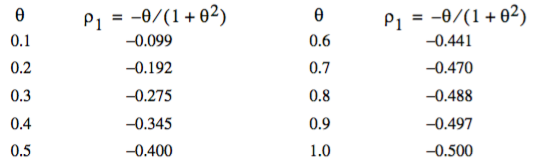

.

It is also possible to observe the autocorrelation at lag 1 by plotting $Y_{t}$ versus $Y_{t-1}$ as follows:

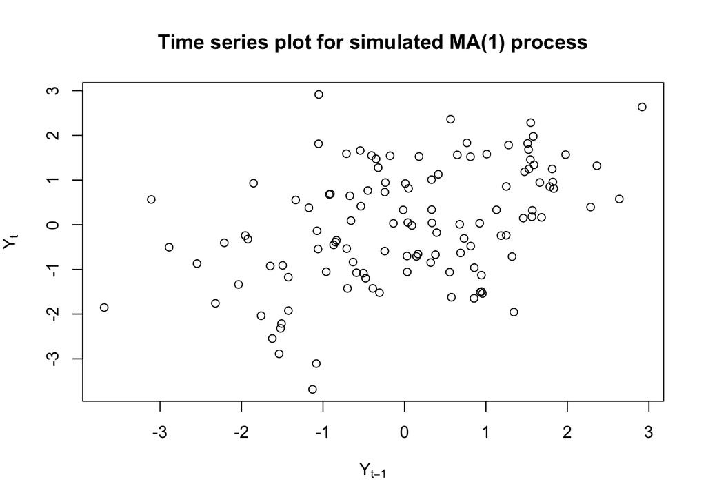

And, we can check the pattern of autocorrelation at lag 2 with the following plot which is a strong visualization of the zero autocorrelation at lag 2 for MA(1) model.

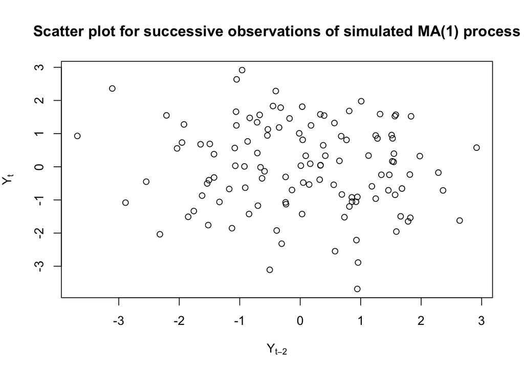

```r
data(ma1.2.s)
plot(y=ma1.2.s,x=zlag(ma1.2.s,2),ylab=expression(Y[t]),
     xlab=expression(Y[t-2]),type='p',main="Scatter plot for successive observations of simulated MA(1) process")
```

The following time series plot visualises an MA(1) series simulated with $\theta=0.9$, correspondingly $\rho_{1}=-0.497$. So, there is a moderately strong negative correlation at lag 1.

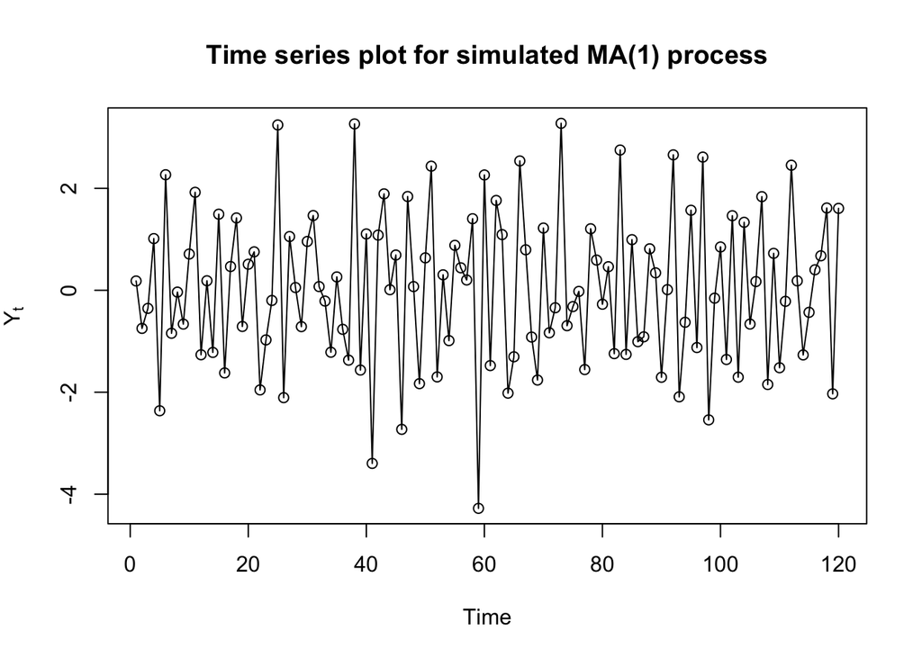

```r
data(ma1.1.s)
plot(ma1.1.s,ylab=expression(Y[t]),type='o',main="Time series plot for simulated MA(1) process")
```

This correlation can be seen in the plot of the series since consecutive observations tend to be on opposite sides of the zero mean. If an observation is above the mean level of the series, then the next observation tends to be below the mean.

The negative lag 1 autocorrelation is even more apparent in the following plot:

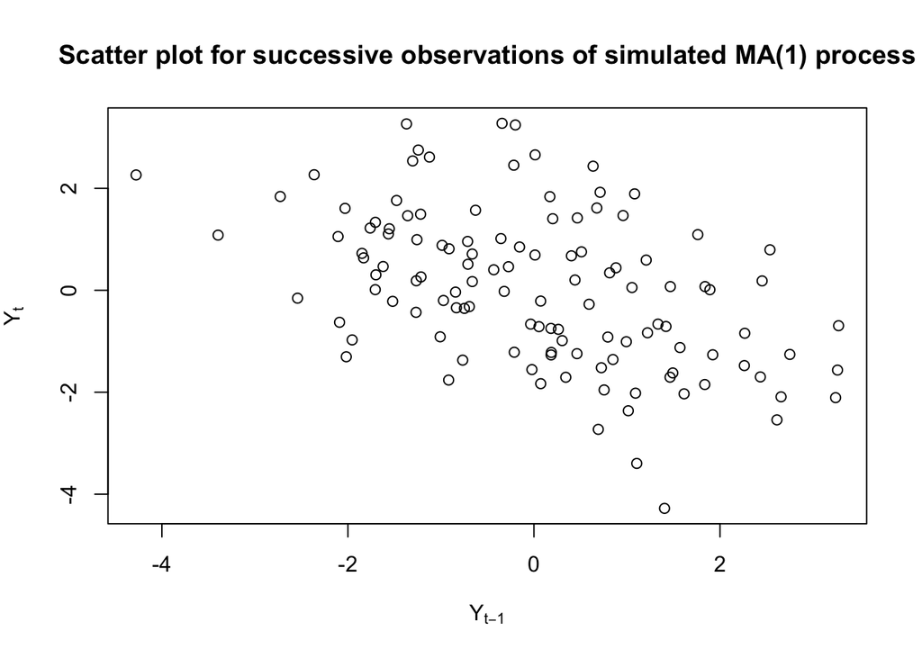

```r
plot(y=ma1.1.s,x=zlag(ma1.1.s),ylab=expression(Y[t]), xlab=expression(Y[t-1]),
     type='p',main="Scatter plot for successive observations of simulated MA(1) process")
```

Notice that MA(1) processes have no autocorrelation beyond lag 1, but by increasing the order of the process, we can obtain higher-order correlations.

## The Second-Order Moving Average Process

The following model is a MA(2) model:

$$Y_{t}=e_{t}-\theta_{1} e_{t-1}-\theta_{2} e_{t-2}.$$

This model has the following properties:

$$\begin{array}{rl}
\gamma_{0} &= Var(e_{t}-\theta_{1}e_{t-1}-\theta_{2}e_{t-2}) \\
&=(1+\theta_{1}^{2}+\theta_{2}^{2})\sigma_{e}^{2}\\
\gamma_{1} &=Cov(Y_{t},Y_{t-1})=(-\theta_{1}+\theta_{1}\theta_{2}) \sigma_{e}^{2}\\
\gamma_{2} &= Cov(Y_{t},Y_{t-2})=-\theta_{2}\sigma_{e}^{2}
\end{array}$$

Thus, for an MA(2) process,

$$\begin{array}{rl}
\rho_{1}&=\frac{-\theta_{1}+\theta_{1}\theta_{2}}{1+\theta_{1}^{2}+\theta_{2}^{2}}\\
\rho_{2}&=\frac{-\theta_{2}}{1+\theta_{1}^{2}+\theta_{2}^{2}}\\
\rho_{k}&=0\text{, for } k=3,4,\dots
\end{array}$$

A time series plot of a simulation of this MA(2) process is shown below:

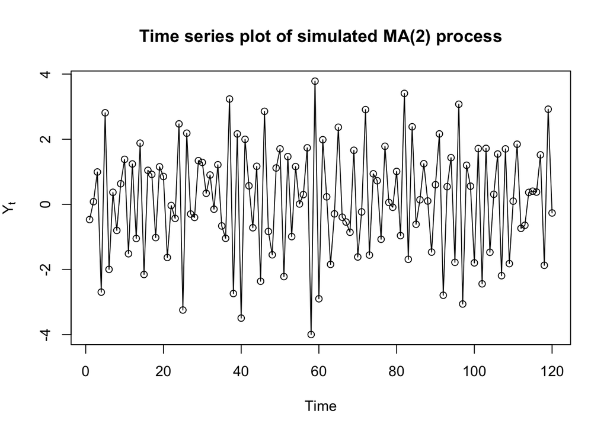

```r
data(ma2.s)
plot(ma2.s,ylab=expression(Y[t]),type='o',main="Time series plot of simulated MA(2) process")
```

The series tends to move back and forth across the mean in one time unit.

This reflects the fairly strong negative autocorrelation at lag 1. This information is useful in identifying MA(2) series in practice.

We observe strong negative correlation between $Y_{t}$ and $Y_{t-1}$.

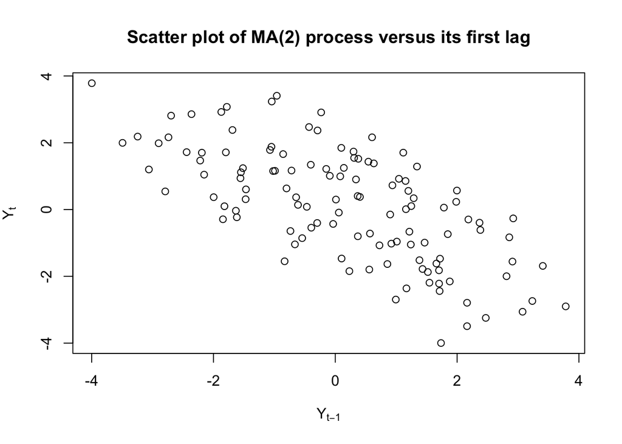

Also, we observe weak positive correlation between $Y_{t}$ and $Y_{t-2}$.

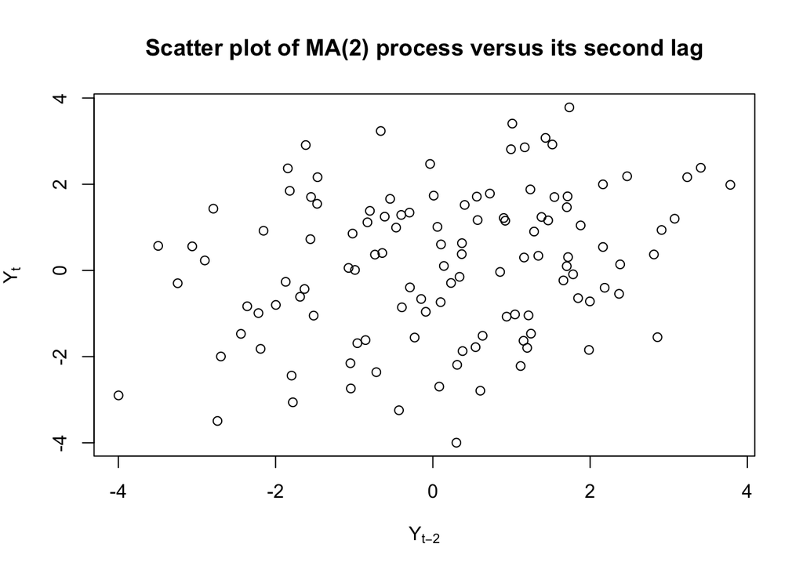

And, there is nearly no correlation between $Y_{t}$ and $Y_{t-3}$ and so forth.

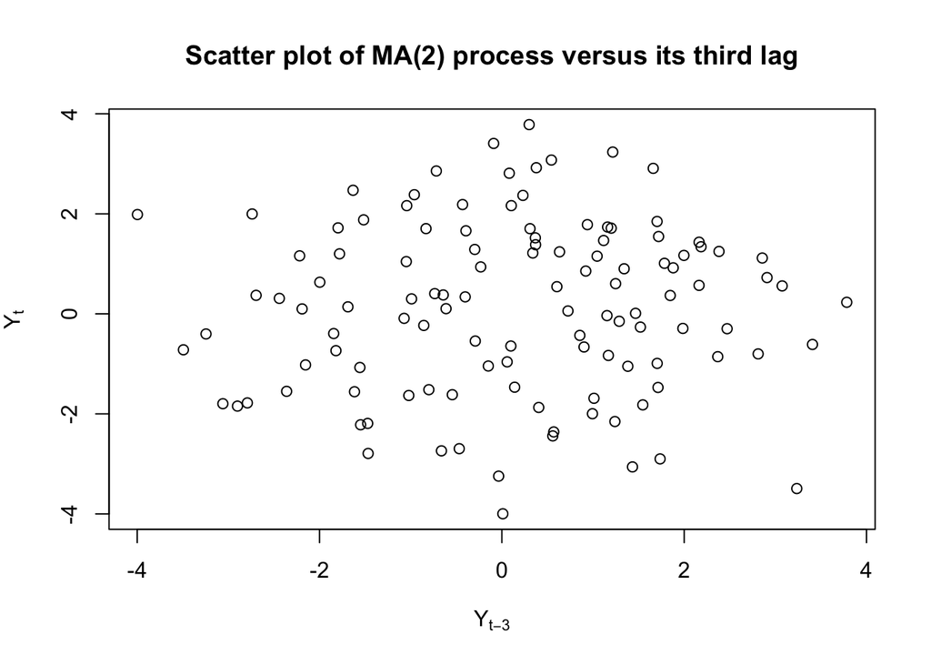

## The General MA(q) Process

The formulation of general MA(q) process is as follows:

$$Y_{t}=e_{t}-\theta_{1} e_{t-1}-\theta_{2} e_{t-2}-\cdots -\theta_{q} e_{t-q}.$$

We have the following autocorrelation result for MA(q) process:

$$\begin{array}{rl}
\rho_{k}&=\frac{-\theta_{k}+\theta_{1}\theta_{k+1}+\theta_{2}\theta_{k+2}+\dots+\theta_{q-k}\theta_{q}}{1+\theta_{1}^{2}+\theta_{2}^{2}+\dots+\theta_{q}^{2}}\\
\rho_{k}&=0\text{, for } k>q
\end{array}$$

The autocorrelation function “cuts off” after lag q; that is, it is zero.

The following App displays time series, ACF and partial-ACF plots for general MA(q) process up to $q=4$.

[interactive chart not shown]

# Autoregressive Processes

The autoregressive (AR) processes provide models for alternative autocorrelation patterns than the MA(q) process can handle. AR processes put regression on themselves. A pth-order autoregressive process $\{Y_{t}\}$ satisfies the following equation:

$$Y_{t}=\phi_{1}Y_{t-1}+\phi_{2}Y_{t-2}+\cdots+\phi_{p}Y_{t-p}+e_{t}.$$

The current value of the series $Y_{t}$ is a linear combination of the $p$ most recent past values of itself plus an error term $e_{t}$ that incorporates everything new in the series at time $t$ that is not explained by the past values.

## The First-Order Autoregressive Process

The model formulation of the first-order AR, namely AR(1), model is

$$Y_{t}=\phi Y_{t-1}+e_{t}.$$

Here we assume that the series mean is zero. So, we obtain the following:

$$\begin{array}{rl}
\gamma_{0}&=\frac{\sigma_{e}^{2}}{1-\phi^{2}},\\
\gamma_{k}&=\phi^{k}\frac{\sigma_{e}^{2}}{1-\phi^{2}}
\end{array}$$

and

$$\rho_{k}=\frac{\gamma_{k}}{\gamma_{0}}=\phi^{k},$$

for $k=1,2,3,\dots$.

Since $\phi < 1$, the magnitude of the autocorrelation function decreases exponentially as the number of lags, $k$, increases. If $0 <\phi< 1$, all correlations are positive; if $-1 <\phi< 0$, the lag 1 autocorrelation is negative $(\rho_{1} = \phi)$ and the signs of successive autocorrelations alternate from positive to negative, with their magnitudes decreasing exponentially.

ACF plots of several autocorrelations for AR(1) process are shown below:

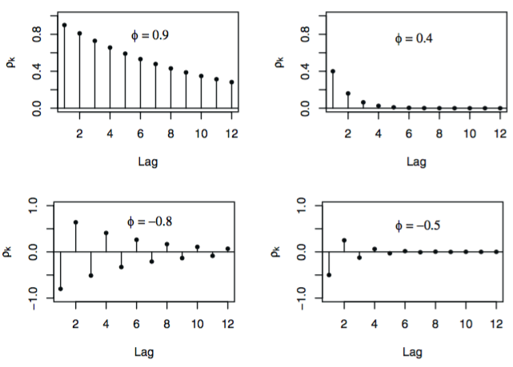

,

Notice that for $\phi$ near $\pm 1$, the exponential decay is quite slow, but for smaller $\phi$, the decay is quite rapid. With $\phi$ near $\pm 1$, the strong correlation will extend over many lags and produce a relatively smooth series if $\phi$ is positive and a very jagged series if $\phi$ is negative.

We have time series plot of a simulated AR(1) process with $\phi = 0.9$.

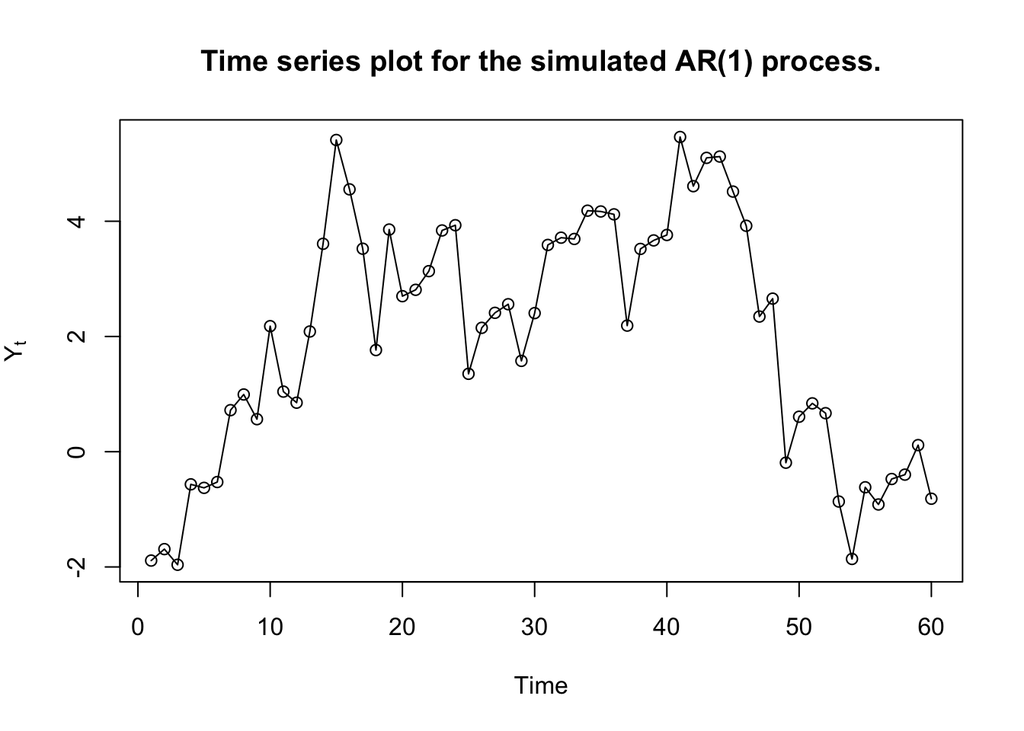

```r
data(ar1.s)
plot(ar1.s,ylab=expression(Y[t]),type='o',
     main="Time series plot for the simulated AR(1) process.")
```

The series rarely crosses its theoretical mean of zero and it seems that there are several trends in this series. This is due to the strong autocorrelation of neighboring values of the series.

The ACF for this series is shown below:

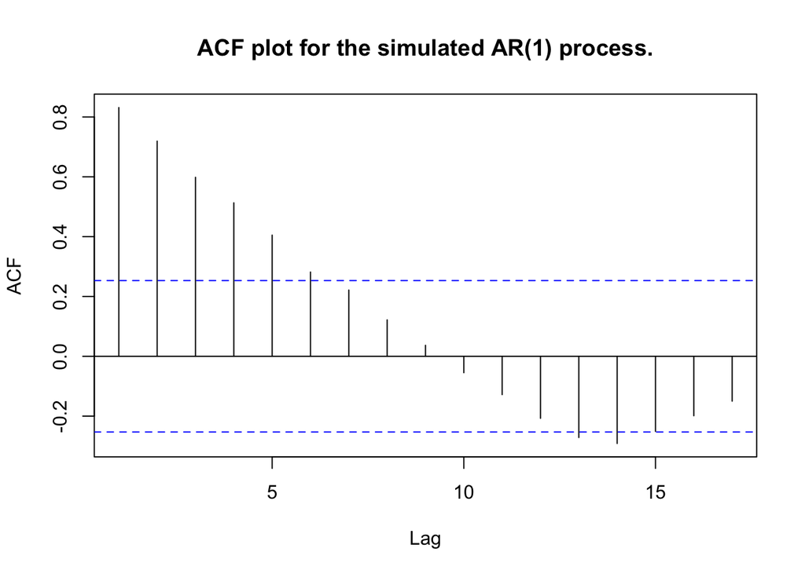

```r
acf(ar1.s,main="ACF plot for the simulated AR(1) process.")
```

We observe the expected exponential decay in the ACF plot of this series. Also, we have high correlation between $Y_{t}$ and $Y_{t-1}$, $Y_{t}$ and $Y_{t-2}$, and $Y_{t}$ and $Y_{t-3}$. So, AR(1) has autocorrelation at lags 1, 2, 3, and so on.

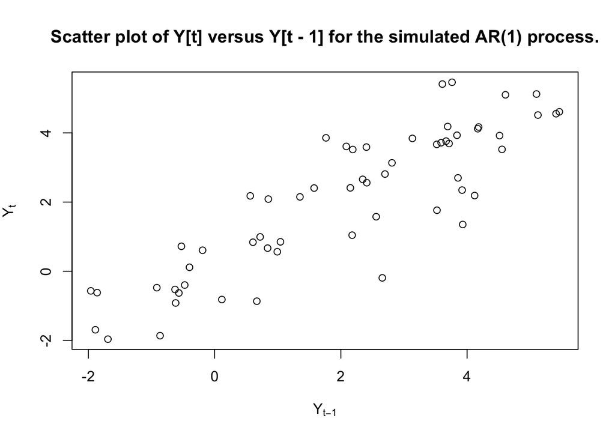

```r
plot(y=ar1.s,x=zlag(ar1.s),ylab=expression(Y[t]),xlab=expression(Y[t-1]),type='p',
     main=paste0("Scatter plot of ", expression(Y[t]) , " versus ", expression(Y[t-1]) , " for the simulated AR(1) process."))
```

At lag 2, $\rho_{2}=0.9^{2} = 0.81$.

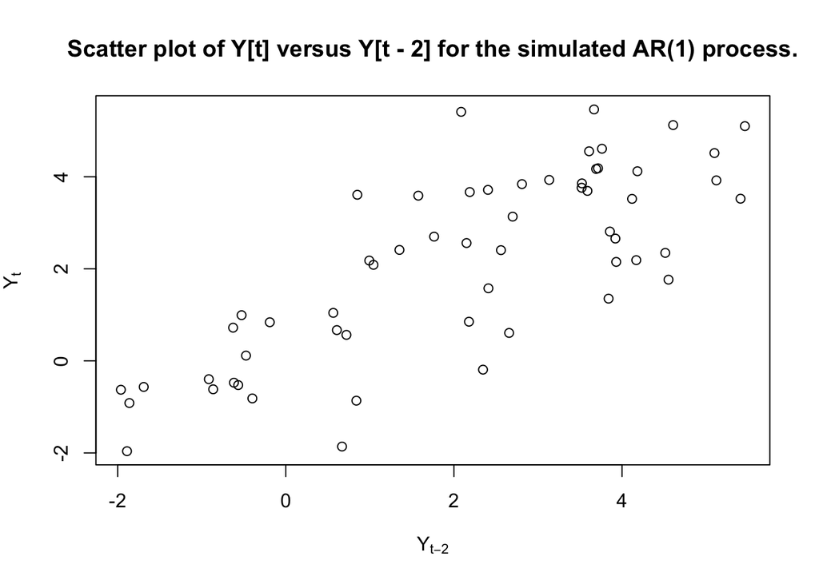

At lag 3, it is still high $\rho_{3}=0.9^{3} = 0.729$.

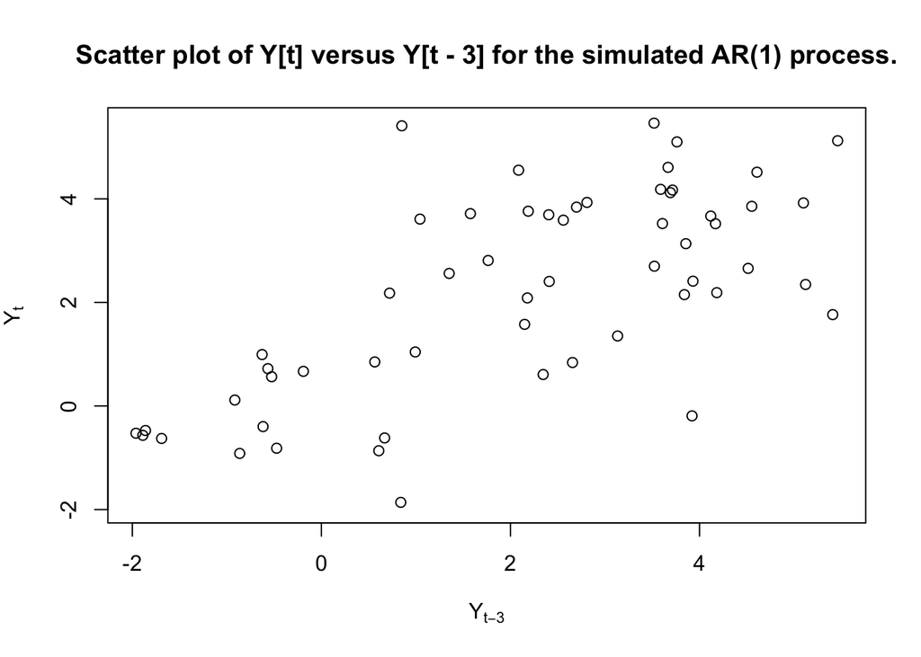

```r
plot(y=ar1.s,x=zlag(ar1.s,3),ylab=expression(Y[t]),xlab=expression(Y[t-3]),type='p',
     main=paste0("Scatter plot of ", expression(Y[t]) , " versus ", expression(Y[t-3]) , " for the simulated AR(1) process."))
```

The PACF for this series is shown below:

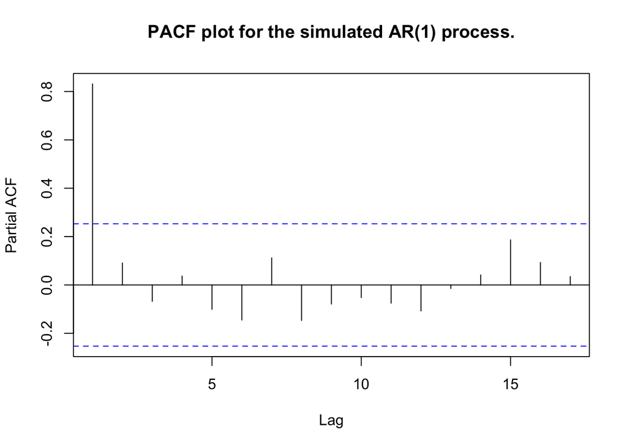

```r
pacf(ar1.s,main="PACF plot for the simulated AR(1) process.")
```

PACF of AR(1) process has a positive or negative spike at lag 1 depending on the sign of $\phi$ then cuts off.

## The Second-Order Autoregressive Process

Model formulation of a second order AR, namely AR(2), process is as the following:

$$Y_{t}=\phi_{1}Y_{t-1}+\phi_{2}Y_{t-2}+e_{t}.$$
where we assume that $e_{t}$ is independent of $Y_{t-1},Y_{t-2},Y_{t-3},\dots$. The autocovariance and autocorrelation functions of an AR(2) process are

$$\gamma_{k}=\phi_{1}\gamma_{k-1}+\phi_{2}\gamma_{k-2}$$

and

$$\rho_{k}=\phi_{1}\rho_{k-1}+\phi_{2}\rho_{k-2}.$$

These equations are called the Yule-Walker equation. Due to the nature of these equations, the autocorrelation function of AR(2) process can assume a wide variety of shapes.

In all cases, the magnitude of $\rho_{k}$ dies out exponentially fast as the lag $k$ increases.

Illustrations of the possible shapes are given below:

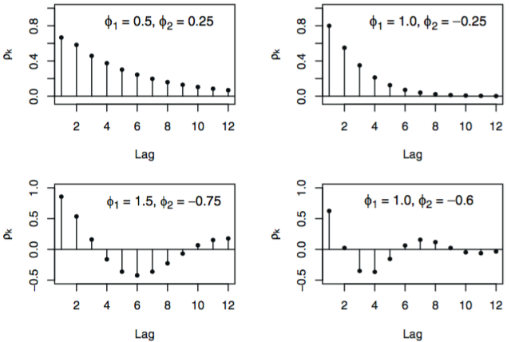

.

The time series plot of a simulated AR(2) series with $\phi_{1} = 1.5$ and $\phi_{2} = -0.75$ is shown below:

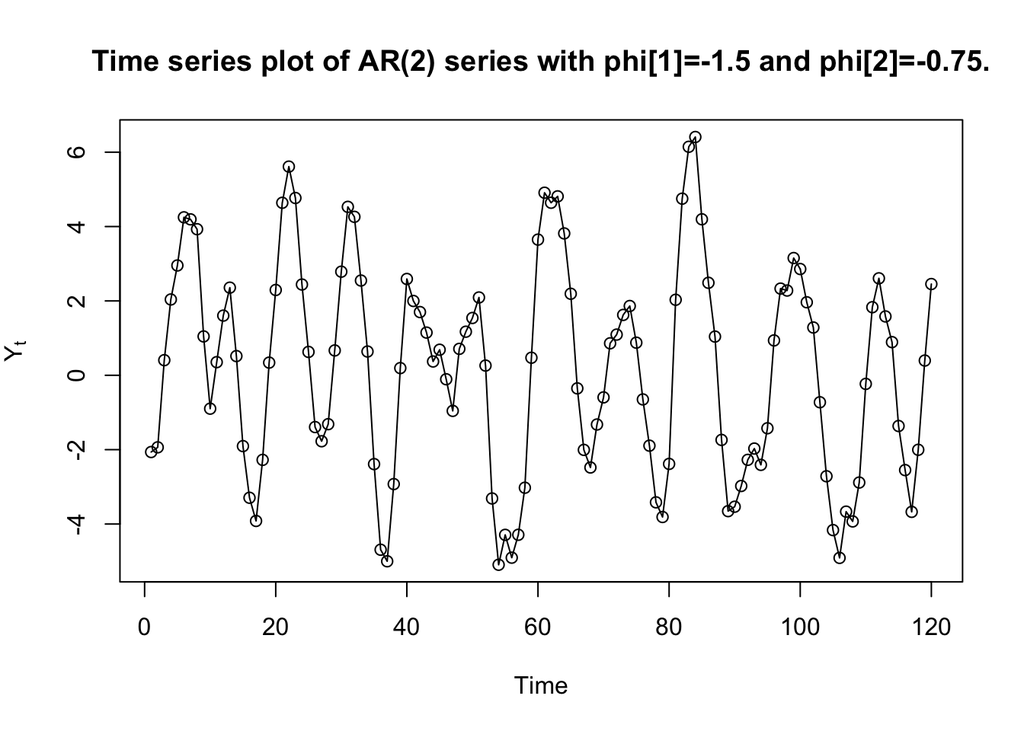

The periodic behavior of AR(2) process is clearly seen in this plot.

The variance for AR(2) process is as follows:

$$\gamma_{0}=\bigg(\frac{1-\phi_{2}}{1+\phi_{2}}\bigg)\frac{\sigma_{e}^{2}}{(1-\phi_{2})^{2}-\phi_{1}^{2}}.$$

PACF of AR(2) process is shown below:

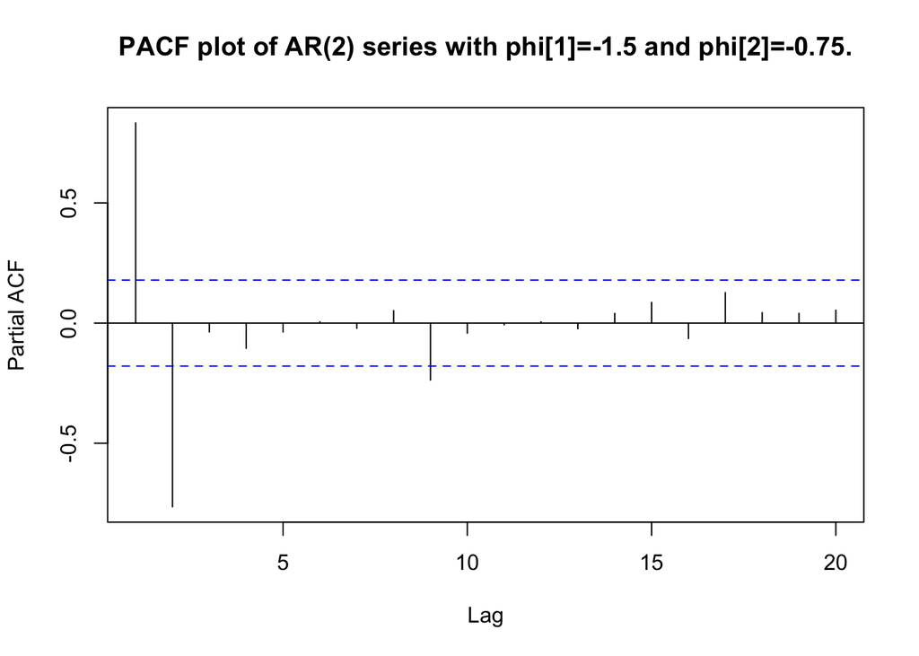

```r
pacf(ar2.s,main=paste0("PACF plot of AR(2) series with ",
                       expression(phi[1]), "=-1.5 and ", expression(phi[2]),"=-0.75."))
```

PACF of AR(2) process cuts off after lag 2.

## The General Autoregressive Process

Model formulation of a general AR, namely AR(p), process is as the following:

$$Y_{t}=\phi_{1}Y_{t-1}+\phi_{2}Y_{t-2}+\cdots+\phi_{p}Y_{t-p}+e_{t}.$$
where we assume that $e_{t}$ is independent of $Y_{t-1},Y_{t-2},Y_{t-3},\dots$.

The general Yule-Walker equations for this process are

$$\begin{array}{rl}
\rho_{1}&=\phi_{1}+\phi_{2}\rho_{1}+\phi_{3}\rho_{2}+\dots+\phi_{p}\rho_{p-1}\\
\rho_{2}&=\phi_{1}\rho_{1}+\phi_{2}+\phi_{3}\rho_{1}+\dots+\phi_{p}\rho_{p-2}\\
\vdots\\
\rho_{p}&=\phi_{1}\rho_{p-1}+\phi_{2}\rho_{p-2}+\phi_{3}\rho_{p-3}+\dots+\phi_{p}\\
\end{array}$$

Given numerical values for $\phi_{1}, \phi_{2},\dots, \phi_{p}$, these linear equations can be solved to obtain numerical values for $\rho_{1}, \rho_{2},\dots, \rho_{p}$. And the following equation is used to find variance of general AR(p) process:

$$\gamma_{0}=\frac{\sigma_{e}^{2}}{1-\phi_{1}\rho_{1}-\phi_{2}\rho_{2}-\dots -\phi_{p}\rho_{p}}.$$

The autocorrelation at lag $k$ will be a linear combination of exponentially decaying terms and damped sine wave terms.

The following App displays time series, ACF and partial-ACF plots for general AR(p) process up to $p=4$.

[interactive chart not shown]

ACF of AR(p) process tails of as a mixture of exponential decays or damped sine waves, which appear if some roots of difference equation are complex.

PACF of AR(p) process will vanish after lag p.

# The Autoregressive Moving Average Model

When we assume that the series is partly autoregressive and partly moving average, we obtain a quite general ARMA(p,q) time series model.

$$Y_{t}=\phi_{1}Y_{t-1}+\phi_{2}Y_{t-2}+\cdots+\phi_{p}Y_{t-p}+e_{t}-\theta_{1}e_{t-1}-\theta_{2}e_{t-2}-\cdots-\theta_{q}e_{t-q}.$$

An ARMA(p.q) process is an autoregressive moving average process of orders p and q.

## The ARMA(1,1) Model

When we set $p=1$ and $q=1$ in the general formulation of ARMA(1,1) model, we get the following model:

$$Y_{t}=\phi Y_{t-1}+e_{t}-\theta_{1}e_{t-1}.$$

We have the following characteristics for the AMRA(1,1) model:

$$\begin{array}{rl}
\gamma_{0}&=\phi\gamma_{1}+[1-\theta (\phi-\theta)]\sigma_{e}^{2}\\
\gamma_{1}&=\phi\gamma_{0}-\theta\sigma_{e}^{2}\\
\gamma_{k}&=\phi\gamma_{k-1}, \text{ for } k\geq2.
\end{array}$$

Correspondingly, we obtain the following for variance of the process

$$\gamma_{0}=\frac{(1-2\phi\theta+\theta^{2})}{1-\phi^{2}}\sigma_{e}^{2}$$

and for the autocorrelation at lag $k$

$$\rho_{k}=\frac{(1-\theta\phi)(\phi-\theta)}{1-2\phi\theta+\theta^{2}}\phi^{k-1}$$

for $k\geq 1$.

The autocorrelation function of ARMA(1,1) process decays exponentially as the lag $k$ increases. The damping factor is $\phi$, but the decay starts from initial value $\rho_{1}$, which also depends on $\theta$.

The following plots show time series and ACF plots of a simulated ARMA(1,1) process with $\phi = 0.7$ and $\theta = -0.2$.

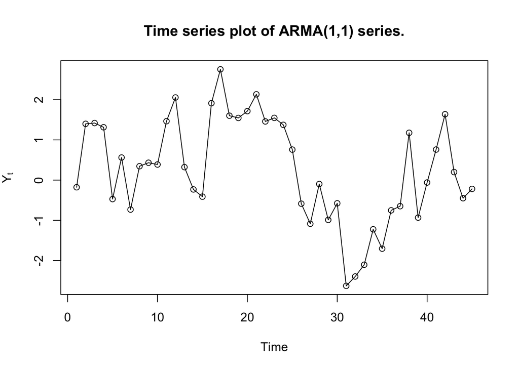

```r
sim.data = arima.sim(list(order = c(1,0,1), ar = 0.7, ma =-0.2 ), n = 45)
arma1.1 = ts(sim.data)
plot(arma1.1,ylab=expression(Y[t]),type='o',main=paste0("Time series plot of ARMA(1,1) series."))
```

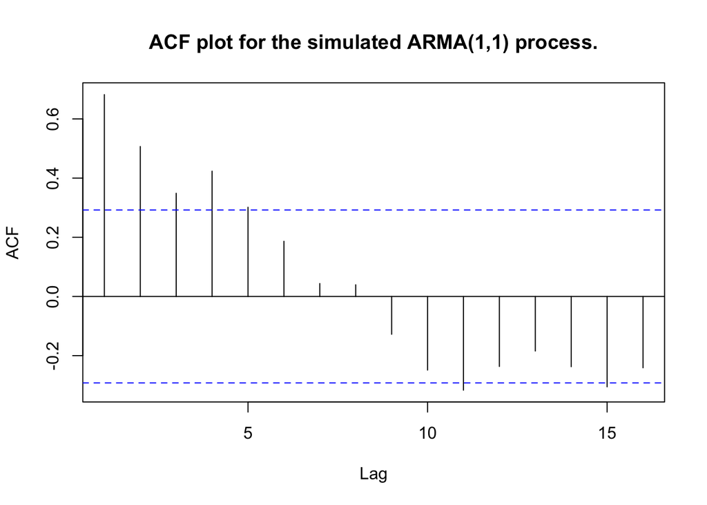

```r
acf(arma1.1,main="ACF plot for the simulated ARMA(1,1) process.")
```

The following App displays time series, ACF and partial-ACF plots for general ARMA(p,q) process up to $p=4$ and $q=4$.

[interactive chart not shown]

# Summary

In this module, we studied basic autoregressive (AR), moving average (MA) and mixed autoregressive moving average (ARMA) processes and their main characteristics. It is important to understand the autocorrelation properties of these models and the various representations of the models to identify models in practice.